# Chapter 1

```r
require(data.table)
require(ggplot2)
theme_set(
    theme_bw(base_size = 14, base_family = "Lato") +
    theme(panel.grid = element_line(size = 0.3, color = "gray90"),
          panel.border = element_blank())
)
```

# 1.1 Reading data from a csv file

The workhorse function for reading data from a CSV file is `fread()`. This function works similarly to `base::read.csv()` or `readr::read_csv()` or `pandas.read_csv()`, it assumes (one of) the default separator between columns is `comma (,)`.

We’re going to be looking some cyclist data from Montréal. Here’s the [original page](http://donnees.ville.montreal.qc.ca/dataset/velos-comptage) (in French) but it’s already included in this repository (`data/bikes.csv` ). We’re using the data from 2012.

This dataset is a list of how many people were on 7 different bike paths in Montreal, each day.

```r
broken_dt <- fread("../data/bikes.csv")
```

```r
head(broken_dt, 3)
```

```
#>          Date Berri 1 Br\xe9beuf (donn\xe9es non disponibles)
#> 1: 01/01/2012      35                                      NA
#> 2: 02/01/2012      83                                      NA
#> 3: 03/01/2012     135                                      NA
#>    C\xf4te-Sainte-Catherine Maisonneuve 1 Maisonneuve 2 du Parc
#> 1:                        0            38            51      26
#> 2:                        1            68           153      53
#> 3:                        2           104           248      89
#>    Pierre-Dupuy Rachel1 St-Urbain (donn\xe9es non disponibles)
#> 1:           10      16                                     NA
#> 2:            6      43                                     NA
#> 3:            3      58                                     NA
```

You’ll notice that something wrong with the column names! Fortunately, `fread` has a bunch of options that will let us fix that, though. Here we’ll

- set the column separator explicitly to a `;`
- set the encoding to ‘latin1’ (the default is ‘utf8’)

Do it again:

```r
bikes <- fread("../data/bikes.csv", sep = ";", encoding = "Latin-1", fill = TRUE)
head(bikes, 3) # looks OK
```

```
#>          Date Berri 1 Brébeuf (données non disponibles)
#> 1: 01/01/2012      35                                NA
#> 2: 02/01/2012      83                                NA
#> 3: 03/01/2012     135                                NA
#>    Côte-Sainte-Catherine Maisonneuve 1 Maisonneuve 2 du Parc Pierre-Dupuy
#> 1:                     0            38            51      26           10
#> 2:                     1            68           153      53            6
#> 3:                     2           104           248      89            3
#>    Rachel1 St-Urbain (données non disponibles)
#> 1:      16                                  NA
#> 2:      43                                  NA
#> 3:      58                                  NA
```

# 1.2 `data.table` object

`data.table`, in its [title](https://github.com/Rdatatable/data.table/blob/master/DESCRIPTION), call itself an extension of `data.frame` which means two things:

- it inherits all features of `data.frame`, everything you can do with `data.frame` is applicable to `data.table`.
- it has its own set of functions to manipulate (aggregate, add, modify, delete, join, …) data efficiently.

```r
class(bikes)
```

```
#> [1] "data.table" "data.frame"
```

```r
is.data.table(bikes)
```

```
#> [1] TRUE
```

```r
str(bikes)
```

```
#> Classes 'data.table' and 'data.frame':   310 obs. of  10 variables:
#>  $ Date                               : chr  "01/01/2012" "02/01/2012" "03/01/2012" "04/01/2012" ...
#>  $ Berri 1                            : int  35 83 135 144 197 146 98 95 244 397 ...
#>  $ Brébeuf (données non disponibles)  : logi  NA NA NA NA NA NA ...
#>  $ Côte-Sainte-Catherine              : int  0 1 2 1 2 0 2 1 2 3 ...
#>  $ Maisonneuve 1                      : int  38 68 104 116 124 98 80 62 165 238 ...
#>  $ Maisonneuve 2                      : int  51 153 248 318 330 244 108 98 432 563 ...
#>  $ du Parc                            : int  26 53 89 111 97 86 53 64 198 275 ...
#>  $ Pierre-Dupuy                       : int  10 6 3 8 13 4 6 11 12 18 ...
#>  $ Rachel1                            : int  16 43 58 61 95 75 54 63 173 241 ...
#>  $ St-Urbain (données non disponibles): logi  NA NA NA NA NA NA ...
#>  - attr(*, ".internal.selfref")=<externalptr>
```

# 1.3 Selecting a column

There are several ways to select a column from a `data.table` object.

- Like a normal `data.frame`

```r
bikes[, "Berri 1"]  # character sub-setting
```

```
#>      Berri 1
#>   1:      35
#>   2:      83
#>   3:     135
#>   4:     144
#>   5:     197
#>  ---
#> 306:    2405
#> 307:    1582
#> 308:     844
#> 309:     966
#> 310:    2247
```

```r
bikes[, 2L]         # integer sub-setting, not recommended
```

```
#>      Berri 1
#>   1:      35
#>   2:      83
#>   3:     135
#>   4:     144
#>   5:     197
#>  ---
#> 306:    2405
#> 307:    1582
#> 308:     844
#> 309:     966
#> 310:    2247
```

- The `data.table` way

```r
bikes[, .(`Berri 1`)] # use backticks to select non-syntactic names
```

```
#>      Berri 1
#>   1:      35
#>   2:      83
#>   3:     135
#>   4:     144
#>   5:     197
#>  ---
#> 306:    2405
#> 307:    1582
#> 308:     844
#> 309:     966
#> 310:    2247
```

```r
## or
bikes[, list(`Berri 1`)]
```

```
#>      Berri 1
#>   1:      35
#>   2:      83
#>   3:     135
#>   4:     144
#>   5:     197
#>  ---
#> 306:    2405
#> 307:    1582
#> 308:     844
#> 309:     966
#> 310:    2247
```

```r
## be noted that `data.table` returns vector when you do not use .() or list()
bikes[, `Berri 1`][1:10] # print out the first 10 values
```

```
#>  [1]  35  83 135 144 197 146  98  95 244 397
```

# 1.4 Plotting

Unlike Python’s `pandas`, `data.table` does not support built-in plotting feature because it is unnecessary. The R world is rich of packages for making beautiful graphics.

My favorite tool is `ggplot2`.

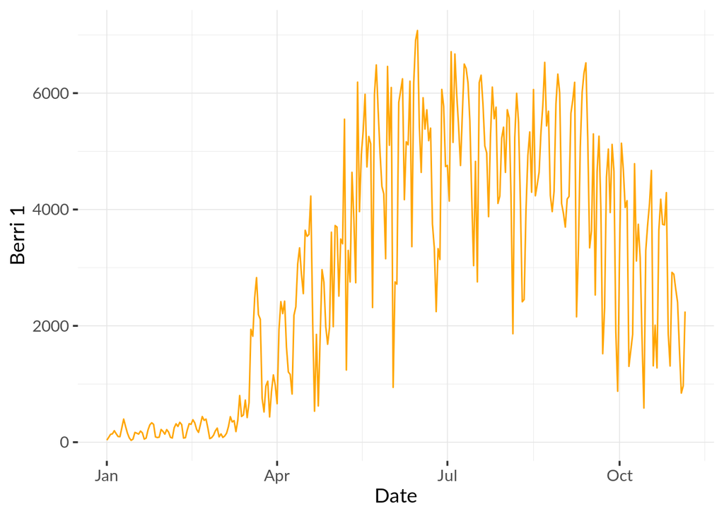

```r
bikes[, Date := as.Date(Date, "%d/%m/%Y")] # don't worry if you don't understand this line
ggplot(bikes, aes(Date, `Berri 1`)) +
    geom_line(color = "orange")
```

# 1.5 Other gems

`data.table::fread()` is famous for its speed, but there’s much more than that. For other wonderful gems of `data.table::fread()`, I highly recommend you to take a loot at this [wiki post](https://github.com/Rdatatable/data.table/wiki/Convenience-features-of-fread) by `data.table`’s author Matt Dowle.